# Week 9 Project

Taha Ahmad with additions from Kayleah Griffen

2023-04-21

```r
library(tidyverse)
library(httr2)
library(jsonlite)
library(keyring)
```

## Introduction

For this assignment, we’ll be practicing our knowledge of Tidyverse functions by creating vignette examples of the packages that make up Tidyverse. In my case, I wanted to attempt going over the forcats package which focuses on manipulating factor elements in a dataframe, as I have no experience with using it at this point.

### Loading a Dataset

In order to make examples for forcats, we need a dataset loaded into R with categorical data. Preferably both ordinal and nominal. The dataset I have chosen is Employee Attrition and Factors from Kaggle https://www.kaggle.com/datasets/thedevastator/employee-attrition-and-factors. We begin by loading the data through the Kaggle API. After loading it in we take a subset of the data with a few columns and rows that will be relevant with the examples.

```r
### INSTRUCTIONS FOR FIRST TIME (provided by Taha) ###

# On Windows:
# 1. If you don't already have a Kaggle account, creating one is the first step.
# 2. Set the username variable to your Kaggle username.
# 3. From your Kaggle account page generate a token, this will download a file that you can open up in a code editor and copy the token from.
# 4. Once you have the token generated, if you run the code chunk keyring::key_set() will ask you to insert a password. That's going to be this token.
# 5. If you've already attempted to run this before you may have set a different password. In that case I would run key_delete("APIKeys","kaggle") in a new code block once before running the original code block again.
# 6. If you come back to the project afterwards, whenever you run the first bit of code keyring will ask you for your computer password to access the API key through key_get.

##################################

# username = "tahamad"
username = "kayleahgriffen"
filename = "attrition.zip"

if (!("kaggle" %in% as_vector(key_list()[2]))) {
  key_set("APIKeys","kaggle")
}

api <- request(r"(https://www.kaggle.com/api/v1/datasets/download/thedevastator/employee-attrition-and-factors)")
req <- api %>%
  req_auth_basic(username = username, password = key_get("APIKeys","kaggle")) %>%
  req_method("GET")

resp <- req %>%
  req_perform()

download.file(resp$url, filename, mode="wb", quiet = TRUE)

att_df <- read_csv(filename, show_col_types = FALSE)

att_df <- att_df %>%
  select(Age, Attrition, BusinessTravel, DailyRate, Department, JobRole) %>%
  head(20)

glimpse(att_df)
```

```
## Rows: 20
## Columns: 6
## $ Age            <dbl> 41, 49, 37, 33, 27, 32, 59, 30, 38, 36, 35, 29, 31, 34,…
## $ Attrition      <chr> "Yes", "No", "Yes", "No", "No", "No", "No", "No", "No",…
## $ BusinessTravel <chr> "Travel_Rarely", "Travel_Frequently", "Travel_Rarely", …
## $ DailyRate      <dbl> 1102, 279, 1373, 1392, 591, 1005, 1324, 1358, 216, 1299…
## $ Department     <chr> "Sales", "Research & Development", "Research & Developm…
## $ JobRole        <chr> "Sales Executive", "Research Scientist", "Laboratory Te…
```

### Factors

Our dataframe now has categorical data multiple columns of categorical data. However, let’s focus on the ordinal variable of “BusinessTravel” and nominal variable of “JobRole”. Looking at the glimpse of the dataframe, we actually don’t have any factors as a column type. Forcats can help us fix that!

#### factor()

factor() is the function which lets us create the factor datatype. It has the following arguments:

factor(x = character(), levels, labels = levels, exclude = NA, ordered = is.ordered(x), nmax = NA)

- x is the character vector which we want to factorize. With levels being the different unique values the character vectors can be.
- levels are the specific character values within the data that form the unique values. Factor() will automatically retrieve these unique values but you can specify these if you would like to order the factors or only take certain values as factors. Those left unspecified will turn into NA values.
- labels are new names you can specify for the various different factors. By default the names are the same as the levels, however if you would like to change the names you can from here.
- exclude allows you to input a character vector of unique values that you would not like to be included within your level.
- ordered will take a boolean that sets if the factor variable is ordered or not.
- nmax can be set to an integer that will only allow a maximum number of levels.

##### Examples

Let’s use factor() to turn our dataframe columns of “BusinessTravel” and “JobRole” into factored columns. Notice how we specify the order of levels for “BusinessTravel” as we want to ensure the levels go from least to most amount of travel. A clear order. However, for “JobRole” we set ordered to FALSE as by being a nominal variable, these variables do not actually have a set order.

```r
att_df$BusinessTravel <- factor(att_df$BusinessTravel,levels=c("Non-Travel","Travel_Rarely","Travel_Frequently"))
att_df$JobRole <- factor(att_df$JobRole, ordered = FALSE)
glimpse(att_df)
```

```
## Rows: 20
## Columns: 6
## $ Age            <dbl> 41, 49, 37, 33, 27, 32, 59, 30, 38, 36, 35, 29, 31, 34,…
## $ Attrition      <chr> "Yes", "No", "Yes", "No", "No", "No", "No", "No", "No",…
## $ BusinessTravel <fct> Travel_Rarely, Travel_Frequently, Travel_Rarely, Travel…
## $ DailyRate      <dbl> 1102, 279, 1373, 1392, 591, 1005, 1324, 1358, 216, 1299…
## $ Department     <chr> "Sales", "Research & Development", "Research & Developm…
## $ JobRole        <fct> Sales Executive, Research Scientist, Laboratory Technic…
```

#### levels()

levels() is the function which shows us the levels set to a factor. It has the following arguments:

levels(x)

- x is the factor vector which we want to see the levels of.

##### Examples

Let’s use levels() to see which levels the now factorized column of “JobRole” has.

```r
levels(att_df$JobRole)
```

```
## [1] "Healthcare Representative" "Laboratory Technician"
## [3] "Manager"                   "Manufacturing Director"
## [5] "Research Scientist"        "Sales Executive"
```

### Inspecting Factors

Now that we have factor columns, what exactly else does forcats let us do with them? Well forcats provides for many functions that apply to factor vectors and we’ll go over inspecting factors in this section.

#### fct_count()

fct_count() is the function which allows to get the counts of each value in a factor. It has the following arguments:

fct_count(f, sort = FALSE, prop = FALSE)

- f is the factor vector which we want to see the levels of.
- sort takes a boolean which allows us to sort the data by count value instead of level order if set to true.
- prop takes a boolean which allows us to convert the count to proportions of each level instead.

##### Examples

Let’s use fct_count() to see the counts of people’s travel habits from “BusinessTravel”. Once with sort disabled and once with sort and prop set to TRUE.

```r
fct_count(att_df$BusinessTravel)
```

```
## # A tibble: 3 × 2
##   f                     n
##   <fct>             <int>
## 1 Non-Travel            1
## 2 Travel_Rarely        15
## 3 Travel_Frequently     4
```

```r
fct_count(att_df$BusinessTravel, sort= TRUE, prop = TRUE)
```

```
## # A tibble: 3 × 3
##   f                     n     p
##   <fct>             <int> <dbl>
## 1 Travel_Rarely        15  0.75
## 2 Travel_Frequently     4  0.2
## 3 Non-Travel            1  0.05
```

#### fct_match()

fct_match() is the function which allows to find the presence of values in a factor. It has the following arguments:

fct_match(f, lvls)

- f is the factor vector which we want to see the levels of.
- lvls takes a character vector of each value that you want the presence of checked. Note that you can not check for values that are not in the factor vector itself.

##### Examples

Let’s use fct_match() to see the which rows of our dataframe have the levels of “BusinessTravel” of “Travel_Frequently” and “Non-Travel”.

```r
att_df %>%
  filter(fct_match(att_df$BusinessTravel, c("Travel_Frequently","Non-Travel")))
```

```
## # A tibble: 5 × 6
##     Age Attrition BusinessTravel    DailyRate Department             JobRole
##   <dbl> <chr>     <fct>                 <dbl> <chr>                  <fct>
## 1    49 No        Travel_Frequently       279 Research & Development Research S…
## 2    33 No        Travel_Frequently      1392 Research & Development Research S…
## 3    32 No        Travel_Frequently      1005 Research & Development Laboratory…
## 4    38 No        Travel_Frequently       216 Research & Development Manufactur…
## 5    22 No        Non-Travel             1123 Research & Development Laboratory…
```

#### fct_unique()

fct_unique() is the function which returns the unique factor values. It has the following arguments:

fct_unique(f)

- f is the factor vector which we want to see the levels of.

##### Examples

```r
fct_unique(att_df$BusinessTravel)
```

```
## [1] Non-Travel        Travel_Rarely     Travel_Frequently
## Levels: Non-Travel Travel_Rarely Travel_Frequently
```

### Combining Factors

There are occasions where we’ll have multiple factor vectors of data which we’ll want to combine. Forcats provides for this as well.

#### fct_c()

fct_c() is the function which allows to combine together factor vectors with different levels. It has the following arguments:

fct_c(…)

- … includes each factor vector that you want to combine.

##### Examples

Let’s use fct_c() to combine the two columns “BusinessTravel” and “JobRole” into one.

```r
fct_c(att_df$BusinessTravel,att_df$JobRole)
```

```
##  [1] Travel_Rarely             Travel_Frequently
##  [3] Travel_Rarely             Travel_Frequently
##  [5] Travel_Rarely             Travel_Frequently
##  [7] Travel_Rarely             Travel_Rarely
##  [9] Travel_Frequently         Travel_Rarely
## [11] Travel_Rarely             Travel_Rarely
## [13] Travel_Rarely             Travel_Rarely
## [15] Travel_Rarely             Travel_Rarely
## [17] Travel_Rarely             Non-Travel
## [19] Travel_Rarely             Travel_Rarely
## [21] Sales Executive           Research Scientist
## [23] Laboratory Technician     Research Scientist
## [25] Laboratory Technician     Laboratory Technician
## [27] Laboratory Technician     Laboratory Technician
## [29] Manufacturing Director    Healthcare Representative
## [31] Laboratory Technician     Laboratory Technician
## [33] Research Scientist        Laboratory Technician
## [35] Laboratory Technician     Manufacturing Director
## [37] Research Scientist        Laboratory Technician
## [39] Manager                   Research Scientist
## 9 Levels: Non-Travel Travel_Rarely ... Sales Executive
```

#### fct_unify()

fct_unify() is the function which allows for sharing the levels of different factor vectors with each other. It has the following arguments:

fct_c(fs, levels = lvls_union(fs))

- fs includes each factor vector that you want to combine the levels of.
- levels can be set to a character vector of the specific values that you want shared if you have them.

##### Examples

Let’s use fct_unify() to combine the levels of the two columns “BusinessTravel” and “JobRole” for each column.

```r
businesstrav <- att_df$BusinessTravel
jobrol <- att_df$JobRole
fct_unify(list(businesstrav,jobrol))
```

```
## [[1]]
##  [1] Travel_Rarely     Travel_Frequently Travel_Rarely     Travel_Frequently
##  [5] Travel_Rarely     Travel_Frequently Travel_Rarely     Travel_Rarely
##  [9] Travel_Frequently Travel_Rarely     Travel_Rarely     Travel_Rarely
## [13] Travel_Rarely     Travel_Rarely     Travel_Rarely     Travel_Rarely
## [17] Travel_Rarely     Non-Travel        Travel_Rarely     Travel_Rarely
## 9 Levels: Non-Travel Travel_Rarely ... Sales Executive
##
## [[2]]
##  [1] Sales Executive           Research Scientist
##  [3] Laboratory Technician     Research Scientist
##  [5] Laboratory Technician     Laboratory Technician
##  [7] Laboratory Technician     Laboratory Technician
##  [9] Manufacturing Director    Healthcare Representative
## [11] Laboratory Technician     Laboratory Technician
## [13] Research Scientist        Laboratory Technician
## [15] Laboratory Technician     Manufacturing Director
## [17] Research Scientist        Laboratory Technician
## [19] Manager                   Research Scientist
## 9 Levels: Non-Travel Travel_Rarely ... Sales Executive
```

### Changing Order

In order to explore data we may want to look at different orders of the levels. Forcats allows for multiple different ways to do this.

#### fct_relevel()

fct_relevel() is the function which allows you to manually change the order of factor levels. It has the following arguments:

fct_relevel(.f, …, after = 0L)

- .f is the factor vector you want to relevel.
- … includes a character vector of the new order of the levels or any functions that you might want to relevel by such as sort().
- after is the position you want to place the levels included in … after.

##### Examples

Let’s use fct_relevel() to reverse the ordering of “BusinessTravel”. (fct_reverse() actually does this exact same thing but we won’t be going over it in this vignette).

```r
att_df %>%
  pull(BusinessTravel) %>%
  fct_relevel(c('Travel_Frequently', 'Travel_Rarely', 'Non-Travel'))
```

```
##  [1] Travel_Rarely     Travel_Frequently Travel_Rarely     Travel_Frequently
##  [5] Travel_Rarely     Travel_Frequently Travel_Rarely     Travel_Rarely
##  [9] Travel_Frequently Travel_Rarely     Travel_Rarely     Travel_Rarely
## [13] Travel_Rarely     Travel_Rarely     Travel_Rarely     Travel_Rarely
## [17] Travel_Rarely     Non-Travel        Travel_Rarely     Travel_Rarely
## Levels: Travel_Frequently Travel_Rarely Non-Travel
```

Let’s also showcase the use of the after parameter. Here we move the level “Non-Travel” to after the first position where it previously was.

```r
att_df %>%
  pull(BusinessTravel) %>%
  fct_relevel(c('Non-Travel'), after = 1)
```

```
##  [1] Travel_Rarely     Travel_Frequently Travel_Rarely     Travel_Frequently
##  [5] Travel_Rarely     Travel_Frequently Travel_Rarely     Travel_Rarely
##  [9] Travel_Frequently Travel_Rarely     Travel_Rarely     Travel_Rarely
## [13] Travel_Rarely     Travel_Rarely     Travel_Rarely     Travel_Rarely
## [17] Travel_Rarely     Non-Travel        Travel_Rarely     Travel_Rarely
## Levels: Travel_Rarely Non-Travel Travel_Frequently
```

#### fct_shift()

fct_shift() is the function which allows for moving the order of factors to the left or to the right. It has the following arguments:

fct_shift(f, n = 1L)

- f includes the factor vector that you want to shift the levels of.
- n is a integer which determines what direction and how many levels you’ll be shifting the order in said direction. A postive n shifts all levels n times to the left, while a negative n shifts all levels n times to the right.

##### Examples

Let’s use fct_shift() shift the order of “JobRole” around first to the left and then to the right.

```r
att_df %>%
  pull(JobRole) %>%
  fct_shift(1)
```

```
##  [1] Sales Executive           Research Scientist
##  [3] Laboratory Technician     Research Scientist
##  [5] Laboratory Technician     Laboratory Technician
##  [7] Laboratory Technician     Laboratory Technician
##  [9] Manufacturing Director    Healthcare Representative
## [11] Laboratory Technician     Laboratory Technician
## [13] Research Scientist        Laboratory Technician
## [15] Laboratory Technician     Manufacturing Director
## [17] Research Scientist        Laboratory Technician
## [19] Manager                   Research Scientist
## 6 Levels: Laboratory Technician Manager ... Healthcare Representative
```

```r
att_df %>%
  pull(JobRole) %>%
  fct_shift(-1)
```

```
##  [1] Sales Executive           Research Scientist
##  [3] Laboratory Technician     Research Scientist
##  [5] Laboratory Technician     Laboratory Technician
##  [7] Laboratory Technician     Laboratory Technician
##  [9] Manufacturing Director    Healthcare Representative
## [11] Laboratory Technician     Laboratory Technician
## [13] Research Scientist        Laboratory Technician
## [15] Laboratory Technician     Manufacturing Director
## [17] Research Scientist        Laboratory Technician
## [19] Manager                   Research Scientist
## 6 Levels: Sales Executive Healthcare Representative ... Research Scientist
```

#### fct_infreq()

fct_infreq() is the function which allows for reordering the levels by the frequency they occur. It has the following arguments:

fct_infreq(f)

- f includes the factor vector that you want to shift the levels of.

##### Examples

```r
fct_infreq(att_df$BusinessTravel, ordered = NA)
```

```
##  [1] Travel_Rarely     Travel_Frequently Travel_Rarely     Travel_Frequently
##  [5] Travel_Rarely     Travel_Frequently Travel_Rarely     Travel_Rarely
##  [9] Travel_Frequently Travel_Rarely     Travel_Rarely     Travel_Rarely
## [13] Travel_Rarely     Travel_Rarely     Travel_Rarely     Travel_Rarely
## [17] Travel_Rarely     Non-Travel        Travel_Rarely     Travel_Rarely
## Levels: Travel_Rarely Travel_Frequently Non-Travel
```

#### fct_inseq()

fct_inseq() is the same as fct_infreq() but for numeric values of the level

#### fct_inorder()

fct_inorder() orders the factors by how they appear in the data

fct_inorder(f)

- f includes the factor vector that you want to shift the levels of.

##### Examples

```r
fct_inorder(att_df$BusinessTravel, ordered = NA)
```

```
##  [1] Travel_Rarely     Travel_Frequently Travel_Rarely     Travel_Frequently
##  [5] Travel_Rarely     Travel_Frequently Travel_Rarely     Travel_Rarely
##  [9] Travel_Frequently Travel_Rarely     Travel_Rarely     Travel_Rarely
## [13] Travel_Rarely     Travel_Rarely     Travel_Rarely     Travel_Rarely
## [17] Travel_Rarely     Non-Travel        Travel_Rarely     Travel_Rarely
## Levels: Travel_Rarely Travel_Frequently Non-Travel
```

#### fct_rev()

fct_rev(f)

- f includes the factor vector that you want to shift the levels of.

##### Examples

```r
fct_rev(att_df$BusinessTravel)
```

```
##  [1] Travel_Rarely     Travel_Frequently Travel_Rarely     Travel_Frequently
##  [5] Travel_Rarely     Travel_Frequently Travel_Rarely     Travel_Rarely
##  [9] Travel_Frequently Travel_Rarely     Travel_Rarely     Travel_Rarely
## [13] Travel_Rarely     Travel_Rarely     Travel_Rarely     Travel_Rarely
## [17] Travel_Rarely     Non-Travel        Travel_Rarely     Travel_Rarely
## Levels: Travel_Frequently Travel_Rarely Non-Travel
```

#### fct_reorder()

fct_reorder() reorders the levels by their relationship to another variable

##### Examples

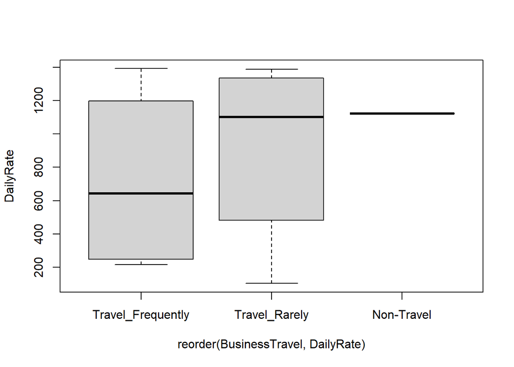

```r
boxplot(data = att_df, DailyRate ~ reorder(BusinessTravel, DailyRate))
```

#### fct_reorder2()

fct_reorder2() reorders levels by their final values

### Change Values

With each value in a factor being mapped to a level, it becomes easy to modify these values through forcats functions operating on the levels.

#### fct_recode()

fct_recode() is the function which allows you to manually change the values of each level. It has the following arguments:

fct_recode(.f, …)

- .f is the factor vector you want to change the values of.
- … includes a mapping of each new value to the existing levels.

##### Examples

Let’s use fct_recode() to change the values of “BusinessTravel”. A simple renaming should suffice here. We’ll change “Non-Travel” to “No”, “Travely_Rarely” to “Some”, and “Travel_Frequently” to “Yes”.

```r
att_df %>%
  pull(BusinessTravel) %>%
  fct_recode(Yes = "Travel_Frequently", Some = "Travel_Rarely", No = "Non-Travel")
```

```
##  [1] Some Yes  Some Yes  Some Yes  Some Some Yes  Some Some Some Some Some Some
## [16] Some Some No   Some Some
## Levels: No Some Yes
```

Let’s also showcase that you can simply rename a single value below.

```r
att_df %>%
  pull(BusinessTravel) %>%
  fct_recode(Yes = "Travel_Frequently")
```

```
##  [1] Travel_Rarely Yes           Travel_Rarely Yes           Travel_Rarely
##  [6] Yes           Travel_Rarely Travel_Rarely Yes           Travel_Rarely
## [11] Travel_Rarely Travel_Rarely Travel_Rarely Travel_Rarely Travel_Rarely
## [16] Travel_Rarely Travel_Rarely Non-Travel    Travel_Rarely Travel_Rarely
## Levels: Non-Travel Travel_Rarely Yes
```

#### fct_other()

fct_other() is a very useful function which allows for replacing certain levels to a single other value. It has the following arguments:

fct_other(f, keep, drop, other_level = “Other”)

- f includes the factor vector that you want to change the levels of.
- keep is a character vector of the values that you would like to keep.
- drop is a character vector of the values that you would like to remove.
- other_level is a string that you would like to change the removed values to, by default this is “Other”.

##### Examples

Let’s use fct_other() on “JobRole” to first change any levels that are not “Research Scientist” and “Laboratory Technician” to other.

```r
att_df %>%
  pull(JobRole) %>%
  fct_other(keep = c("Research Scientist", "Laboratory Technician"))
```

```
##  [1] Other                 Research Scientist    Laboratory Technician
##  [4] Research Scientist    Laboratory Technician Laboratory Technician
##  [7] Laboratory Technician Laboratory Technician Other
## [10] Other                 Laboratory Technician Laboratory Technician
## [13] Research Scientist    Laboratory Technician Laboratory Technician
## [16] Other                 Research Scientist    Laboratory Technician
## [19] Other                 Research Scientist
## Levels: Laboratory Technician Research Scientist Other
```

Afterwards we showcase using drop to only change the levels “Research Scientist” and “Laboratory Technician” to “Unimportant Role” by utilizing the other_level argument.

```r
att_df %>%
  pull(JobRole) %>%
  fct_other(drop = c("Research Scientist", "Laboratory Technician"), other_level = "Unimportant Role")
```

```
##  [1] Sales Executive           Unimportant Role
##  [3] Unimportant Role          Unimportant Role
##  [5] Unimportant Role          Unimportant Role
##  [7] Unimportant Role          Unimportant Role
##  [9] Manufacturing Director    Healthcare Representative
## [11] Unimportant Role          Unimportant Role
## [13] Unimportant Role          Unimportant Role
## [15] Unimportant Role          Manufacturing Director
## [17] Unimportant Role          Unimportant Role
## [19] Manager                   Unimportant Role
## 5 Levels: Healthcare Representative Manager ... Unimportant Role
```